# Maintain your brain, BMI

## bmi

- BMI: `rcal_mybBMI`, `cl2_bmi_fu1`, `cl2_bmi_fu2`, `cl2_bmi_fu3`

These analyses use `bl_adritotal` (as named in the original SPSS file) as the ADRI baseline covariate.

These results exclude those participants who were eligible for fewer than 2 modules but who were randomised. This results in N=6104

Inference for differences in rc_trial_time trend by group_type_id for bmi

## Data summary

```
## # A tibble: 8 x 4
## # Groups:   rc_trial_time [4]
##   rc_trial_time group_type_id  mean    sd
##           <int>         <int> <dbl> <dbl>
## 1             1             1  26.6  4.85
## 2             1             2  26.7  4.74
## 3            10             1  26.3  4.77
## 4            10             2  25.8  4.53
## 5            11             1  26.2  4.80
## 6            11             2  25.8  4.48
## 7            12             1  26.2  4.85
## 8            12             2  25.8  4.54
```

```
## # A tibble: 8 x 3
## # Groups:   rc_trial_time, group_type_id [8]
##   rc_trial_time group_type_id     n
##           <int>         <int> <int>
## 1             1             1  3053
## 2             1             2  3050
## 3            10             1  2096
## 4            10             2  1492
## 5            11             1  1886
## 6            11             2  1345
## 7            12             1  1942
## 8            12             2  1371
```

One person is in the Baseline Sample, but did not have any data at baseline for BMI calculation.

```
##   id_mask rc_trial_time bmi rcal_mybBMI rcal_total_energy
## 1  503244             1  NA          NA                NA
```

## Results

```
##   response adjusted base_3yr_did    LCL   UCL  zstat       pz     Chisq p.value
## 1      bmi       No       -0.044 -0.126 0.038 -1.052 =  0.293 17.088(3)  <0.001
## 2      bmi      Yes       -0.042 -0.125 0.040 -1.011 =  0.312 16.921(3)  <0.001
```

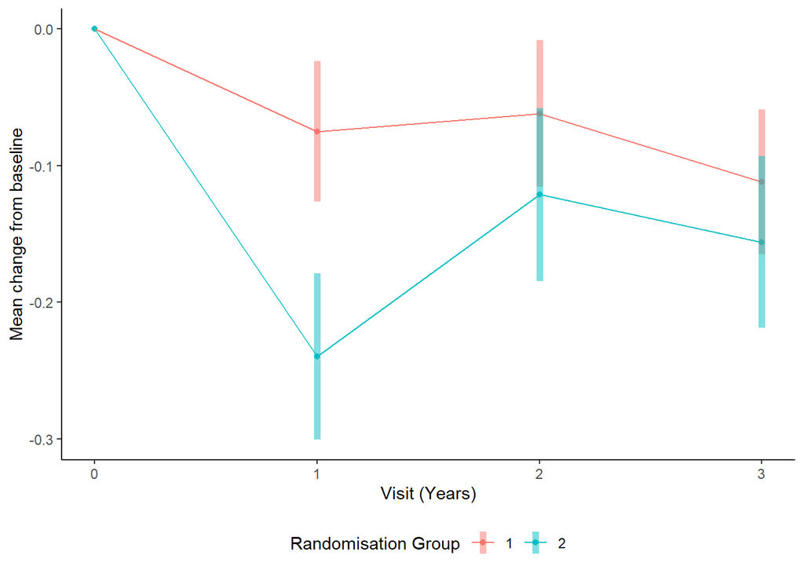

## Result

Covariates included in adjusted models:

- `myb_age`: Age at Baseline
- `myb_gender`: Reported gender
- `cl_edu_yrs`: Years of education
- `rcal_modules_sum`: Number of modules person was eligible for
- `adri_baseline`: ADRI at Baseline

Analyses were run on N=6103 participants.

A linear mixed model with a random effect for patient and fixed effects of time point, randomisation group and their interaction was run. An additional analysis including covariates of myb_age, myb_gender, cl_edu_yrs, rcal_modules_sum, adri_baseline was run. e report estimates of the group difference in the change from baseline to three years follow up with 95% confidence interval, and associated Z statistic and p-value. The units of the effect size are raw BMI units (*not* baseline standardised).

The unadjusted difference between randomisation groups of change from baseline to three year follow up was -0.044 ( 95%CI: -0.126- 0.038,Z=-1.052, p= 0.293) .

The difference between randomisation groups of change from baseline to three year follow up was -0.042 ( 95%CI: -0.125 - 0.04,Z=-1.011,p= 0.312) , adjusting for myb_age, myb_gender, cl_edu_yrs, rcal_modules_sum, adri_baseline.

Analysis by Nancy Briggs and Gordana Popovic on 2024-02-14